# IA 3 - SANYAM JAIN (sj33448)

### Demand Models Laboratory.

#### (Total 40 pts.)

#### Due: Dec. 5

In this assignment you will produce a forecast for sales of carbonated beverages at a supermarket based on real weekly sales information of items in the category for a period of two years. This information is contained in the following three files:

- **CarbBev_IA3.RDS** This is the listing of weekly sales and the corresponding promotional variables for each product at the store.
- **Carb Bev UPC.csv** This includes product information for the different product UPC codes that you will find in the **CarbBev_IA3.RDS** file.
- **Data Measure Definitions.docx** This is a file with descriptions of the columns you will find in the **CarbBev_IA3.RDS** file.

Please take a few minutes to get acquainted with the data.

```r
library(tidyverse)
X <- readRDS("Carb_Bev_IA3.RDS") %>%
  mutate(P  = DOLLARS/UNITS) %>%
  select(-DOLLARS)

U <- U <- read.csv("Carb_Bev_Prod_UPC.csv") %>%
  as_tibble %>%
  mutate(UPC = as.factor(UPC))
```

To make the project more concrete, you will develop a demand model for product UPC = *00-01-12000-80995* and use products UPC = *00-01-49000-02891* and UPC = *00-01-78000-08316* as potential product substitutes, which corresponds to the following description:

```r
U %>%
  filter(UPC == "00-01-49000-02891" |
         UPC == "00-01-12000-80995" |
         UPC == "00-01-78000-08316")
```

| L1 | L2 | L3 | L4 | L5 | L9 | Level | UPC | SY | GE | VEND | ITEM | X.AG.C.1..CATEGORY........................................................00004 | VOL_EQ | PRODUCT.TYPE | PACKAGE | FLAVOR.SCENT | CALORIE.LEVEL | CAFFEINE.INFO | TYPE.OF.SWEETENER | PERCENTAGE.OF.JUICE |
| --- | --- | --- | --- | --- | --- | --- | --- | --- | --- | --- | --- | --- | --- | --- | --- | --- | --- | --- | --- | --- |
| CATEGORY - CARBONATED BEVERAGES | LOW CALORIE SOFT DRINKS | COCA COLA CO | COCA COLA CO | DIET COKE | +DCOKE CLA SODA DI CAFEN 144OZ | 9 | 00-01-49000-02891 | 0 | 1 | 49000 | 2891 | +DCOKE CLA SODA DI CAFEN 144OZ 0 1 49000 2891 1 1 0.7500RP 15636 | 0.75 | SODA | CAN IN FRIDGE PCK BX | COLA | DIET | CAFFEINE | ASPARTAME | NO PERCENT GIVEN |
| CATEGORY - CARBONATED BEVERAGES | LOW CALORIE SOFT DRINKS | DR PEPPER/SNAPPLE GROUP | DR PEPPER/SNAPPLE GROUP | DIET DR PEPPER | +DTDPR PPR SODA DI CAFEN 144OZ | 9 | 00-01-78000-08316 | 0 | 1 | 78000 | 8316 | +DTDPR PPR SODA DI CAFEN 144OZ 0 1 78000 8316 1 1 0.7500RP 16226 | 0.75 | SODA | CAN IN FRIDGE PCK BX | PEPPER | DIET | CAFFEINE | ASPARTAME | MISSING |
| CATEGORY - CARBONATED BEVERAGES | LOW CALORIE SOFT DRINKS | PEPSICO INC | PEPSICO INC | DIET PEPSI | +DPEPS CLA SODA DI CAFEN 144OZ | 9 | 00-01-12000-80995 | 0 | 1 | 12000 | 80995 | +DPEPS CLA SODA DI CAFEN 144OZ 0 1 12000 80995 1 1 0.7500RP 17304 | 0.75 | SODA | CAN IN FRIDGE PCK BX | COLA | DIET | CAFFEINE | ASPARTAME | MISSING |

[output not shown]

3 rows | 1-3 of 21 columns

Our goal is to create a log-log model and *if necessary* embed the demand model in an ARIMA model (Regression with ARIMA errors) that accounts for the auto-correlations in the sales data. As a first attempt we would like to include a demand function of the following form:

$$y=e^{βx} p^α q_1^{γ_1}
q_2^{γ_2}$$

Where the model variables and parameters are defined as follows:

- $y$ : Demand (sales volume)
- $p$ : Price per unit of the focal product.
- $q_i$ : Price per unit of substitute products.
- $x$ : Vector of weighted averages of advertising and display variables for each product
- $β$ : Vector of coefficients for advertising and display variables
- $α,γ_1,γ_2$: Coefficients (elasticity and cross-elasticities) of prices

#### Q1. Create a data set appropriate for the above model (i.e., subset and wrangle the appropriate variables in correct position to execute a simple linear regression model) Then run a TSLM model using only the prices (i.e., $y= p^α$) and examine the results you obtain. Comment on the validity of the model. Plot the time-series of *UNITS* and overly the corresponding time series of fitted values, then comment on the fit of the model. What is the price-elasticity of demand according to this model?**

#### Ans1:

```r
library(dplyr)
library(fpp3)
X %>%
  filter(UPC == "00-01-12000-80995") -> XR

X %>%
  filter(UPC == "00-01-49000-02891" |
         UPC == "00-01-78000-08316" ) %>%
  select(WEEK, ITEM, D, PR, FEAT, P) %>%
  pivot_wider(names_from = ITEM,
              values_from = c(D, PR, FEAT, P)) %>%
  select_if(~sum(is.na(.)) == 0) %>%
  left_join(XR,.,by = "WEEK") %>%
  as_tsibble(index = WEEK) -> XR

TR <- XR %>% filter(WEEK <= 1624)
TE <- XR %>% filter(WEEK >= 1625)
```

```r
mod_simple_linear_reg <- TR %>%
  model(m = TSLM(log(UNITS) ~ log(P)))

mod_simple_linear_reg %>%
  augment %>%
  features(.resid, ljung_box, lag = 10)
```

| .model | lb_stat | lb_pvalue |
| --- | --- | --- |
| m | 7.379917 | 0.6891573 |

[output not shown]

1 row

```r
mod_simple_linear_reg %>% report()
```

```
## Series: UNITS
## Model: TSLM
## Transformation: log(UNITS)
##
## Residuals:
##     Min      1Q  Median      3Q     Max
## -1.6830 -0.2800 -0.0507  0.1733  2.4267
##
## Coefficients:
##             Estimate Std. Error t value Pr(>|t|)
## (Intercept)  10.7070     0.3635   29.45   <2e-16 ***
## log(P)       -4.5949     0.2664  -17.25   <2e-16 ***
## ---
## Signif. codes:  0 '***' 0.001 '**' 0.01 '*' 0.05 '.' 0.1 ' ' 1
##
## Residual standard error: 0.4819 on 92 degrees of freedom
## Multiple R-squared: 0.7638,  Adjusted R-squared: 0.7613
## F-statistic: 297.5 on 1 and 92 DF, p-value: < 2.22e-16
```

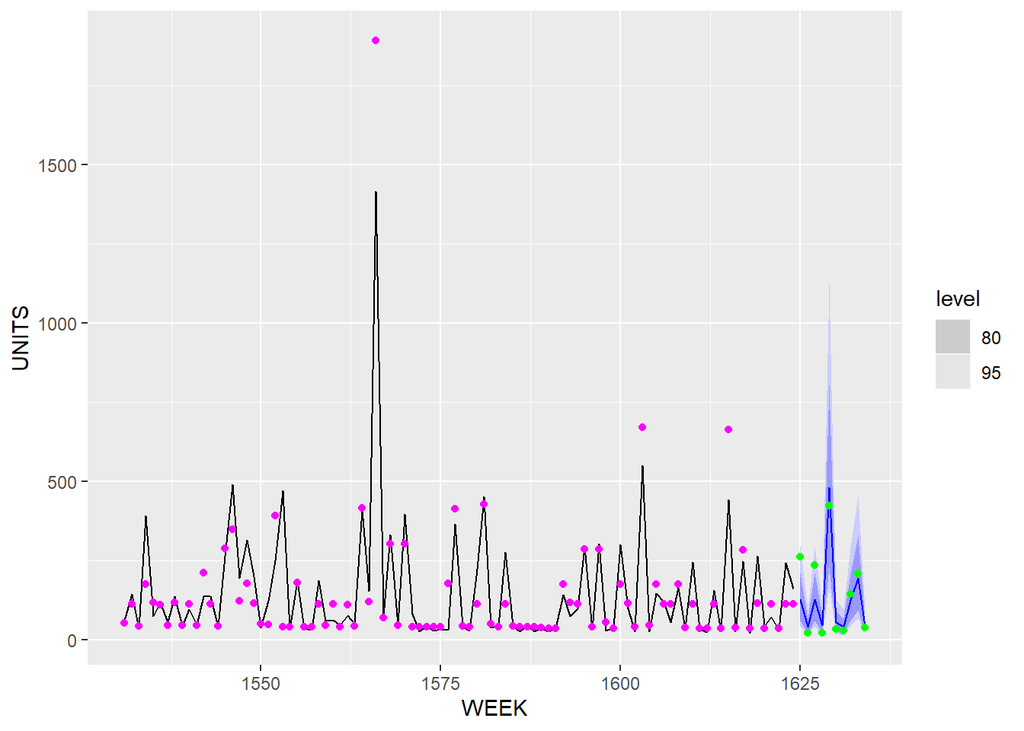

```r
TE %>% select(D, P, FEAT) -> prediction_data


mod_simple_linear_reg %>%
  forecast(new_data = prediction_data) -> forecast_simple_linear


fitted_data_linear <- mod_simple_linear_reg %>%
  augment()

forecast_simple_linear %>%
  autoplot() +
  geom_line(data = TR, mapping = aes(y = UNITS)) +
  geom_point(data = fitted_data_linear, mapping = aes(y = .fitted), col = "magenta") +
  geom_point(data = TE, mapping = aes(y = UNITS), col = "green")
```

Demand Price Elasticity:

The calculated price elasticity of demand suggests that for each one percent change in price, the demand or sales units change by 4.6%. This figure is derived from the coefficient of log(P) in our model, where the response variable is log(UNITS).

#### Q2. Use the training set to fit LASSO regression model (i.e., use the **glmnet** R package ) that includes as candidate model features all the prices, advertisement/promotion and feature variables and their cross-products. Report the set of non-zero coefficients for the lasso solutions corresponding to $\lambda_{min}$ and $\lambda_{1se}$.

#### Ans 2:

```r
library(glmnet)
features_matrix <- model.matrix(~ . - 1 - UPC - VEND - ITEM - UNITS, data = TR
                  %>% mutate(FEAT = factor(FEAT, levels = setdiff(unique(FEAT), c("A+", "C"))),FEAT_2891 = factor(FEAT_2891, levels = setdiff(unique(FEAT_2891), c("A+", "C"))),FEAT_8316 = factor(FEAT_8316, levels = setdiff(unique(FEAT_8316), c("A+", "C"))) ) )
target_log_units <- log(TR$UNITS)

features_matrix <- scale(features_matrix)

set.seed(8)
crossval_model <- cv.glmnet(features_matrix, target_log_units, alpha = 1)

# Extracting coefficients
coefficients_min_lambda <- coef(crossval_model, s = "lambda.min")
coefficients_1se_lambda <- coef(crossval_model, s = "lambda.1se")

# Isolating non-zero coefficients
non_zero_coeffs_min_lambda <- as.matrix(coefficients_min_lambda)
non_zero_coeffs_min_lambda <- non_zero_coeffs_min_lambda[non_zero_coeffs_min_lambda[, 1] != 0, , drop = FALSE]
non_zero_coeffs_min_lambda <- as.data.frame(non_zero_coeffs_min_lambda)

non_zero_coeffs_1se_lambda <- as.matrix(coefficients_1se_lambda)
non_zero_coeffs_1se_lambda <- non_zero_coeffs_1se_lambda[non_zero_coeffs_1se_lambda[, 1] != 0, , drop = FALSE]
non_zero_coeffs_1se_lambda <- as.data.frame(non_zero_coeffs_1se_lambda)

cat("Non-zero coefficients at lambda.min:\n")
```

```
## Non-zero coefficients at lambda.min:
```

```r
print(non_zero_coeffs_min_lambda)
```

```
##                         s1
## (Intercept)    4.495734350
## WEEK          -0.061475318
## D              0.270421141
## FEATNONE      -0.174008312
## FEATB          0.019202570
## P             -0.534913499
## D_8316        -0.009921439
## PR_8316       -0.001894947
## FEAT_2891NONE -0.038462040
## FEAT_8316A    -0.017788942
```

```r
cat("\nNon-zero coefficients at lambda.1se:\n")
```

```
##
## Non-zero coefficients at lambda.1se:
```

```r
print(non_zero_coeffs_1se_lambda)
```

```
##                     s1
## (Intercept)  4.4957343
## D            0.1560493
## FEATNONE    -0.1036826
## P           -0.4775305
```

#### Q3. Use the training set to fit an unrestricted TSLM regression model on the reduced set of explanatory variables identified by The LASSO. Report the coefficients of the full model and comment on the fit of the model and examine the auto-correlations of the residuals of this model. If necessary enhance the reduced model as a regression with ARIMA errors.

#### Ans3:

```r
selected_features_min_lambda <- rownames(non_zero_coeffs_min_lambda)[-1]
selected_features_1se_lambda <- rownames(non_zero_coeffs_1se_lambda)[-1]


unique_selected_features <- unique(c(selected_features_min_lambda, selected_features_1se_lambda))


log_units_formula <- as.formula(paste("log(UNITS) ~", paste(unique_selected_features, collapse = " + ")))


formatted_training_data <- as.data.frame(model.matrix(~ . - 1 - UPC - VEND - ITEM, data = TR
                  %>% mutate(FEAT = factor(FEAT, levels = setdiff(unique(FEAT), c("A+", "C"))),
                             FEAT_2891 = factor(FEAT_2891, levels = setdiff(unique(FEAT_2891), c("A+", "C"))),
                             FEAT_8316 = factor(FEAT_8316, levels = setdiff(unique(FEAT_8316), c("A+", "C"))) ) ))


linear_model_log_units <- lm(log_units_formula, data = formatted_training_data)


summary(linear_model_log_units)
```

```
##
## Call:
## lm(formula = log_units_formula, data = formatted_training_data)
##
## Residuals:
##      Min       1Q   Median       3Q      Max
## -1.45026 -0.18212 -0.00409  0.18548  1.49514
##
## Coefficients:
##                Estimate Std. Error t value Pr(>|t|)
## (Intercept)   12.242399   2.362370   5.182 1.48e-06 ***
## WEEK          -0.002865   0.001514  -1.893   0.0618 .
## D              0.654767   0.122248   5.356 7.29e-07 ***
## FEATNONE      -0.328223   0.152990  -2.145   0.0348 *
## FEATB          0.100859   0.129977   0.776   0.4399
## P             -0.789037   0.094979  -8.307 1.47e-12 ***
## D_8316        -0.031753   0.085507  -0.371   0.7113
## PR_8316       -0.070406   0.104384  -0.674   0.5019
## FEAT_2891NONE -0.153331   0.093090  -1.647   0.1033
## FEAT_8316A    -0.163846   0.239647  -0.684   0.4960
## ---
## Signif. codes:  0 '***' 0.001 '**' 0.01 '*' 0.05 '.' 0.1 ' ' 1
##
## Residual standard error: 0.3849 on 84 degrees of freedom
## Multiple R-squared:  0.8625, Adjusted R-squared:  0.8478
## F-statistic: 58.54 on 9 and 84 DF,  p-value: < 2.2e-16
```

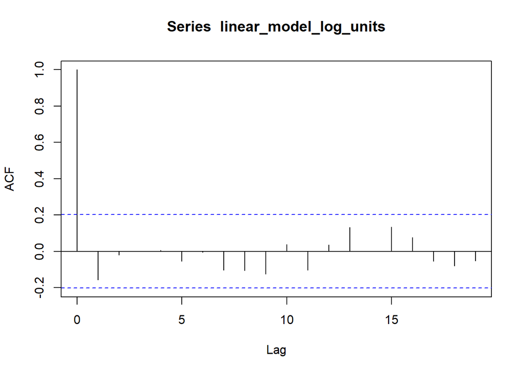

```r
linear_model_log_units <- residuals(linear_model_log_units)

acf(linear_model_log_units)
```

```r
Box.test(linear_model_log_units, lag = 10, type = "Ljung-Box")
```

```
##
##  Box-Ljung test
##
## data:  linear_model_log_units
## X-squared = 6.807, df = 10, p-value = 0.7435
```

```r
autoregressive_model <- arima(linear_model_log_units, order = c(1, 0, 0))
formatted_training_data$AutoregModel_Residuals <- residuals(autoregressive_model)

integrated_linear_model <- lm(log(UNITS) ~ WEEK + D + FEATNONE + P + AutoregModel_Residuals, data = formatted_training_data)

summary(integrated_linear_model)
```

```
##
## Call:
## lm(formula = log(UNITS) ~ WEEK + D + FEATNONE + P + AutoregModel_Residuals,
##     data = formatted_training_data)
##
## Residuals:
##       Min        1Q    Median        3Q       Max
## -0.293989 -0.066970  0.002978  0.068542  0.235452
##
## Coefficients:
##                          Estimate Std. Error t value Pr(>|t|)
## (Intercept)            12.3984502  0.6132005  20.219  < 2e-16 ***
## WEEK                   -0.0029687  0.0003892  -7.628 2.65e-11 ***
## D                       0.6188210  0.0318660  19.419  < 2e-16 ***
## FEATNONE               -0.4123048  0.0323187 -12.757  < 2e-16 ***
## P                      -0.8011943  0.0243564 -32.895  < 2e-16 ***
## AutoregModel_Residuals  1.0032845  0.0292967  34.246  < 2e-16 ***
## ---
## Signif. codes:  0 '***' 0.001 '**' 0.01 '*' 0.05 '.' 0.1 ' ' 1
##
## Residual standard error: 0.102 on 88 degrees of freedom
## Multiple R-squared:  0.9899, Adjusted R-squared:  0.9893
## F-statistic:  1721 on 5 and 88 DF,  p-value: < 2.2e-16
```

The statistics from the integrated model demonstrate a marked enhancement in performance over the initial linear regression approach. The integrated model now accounts for a substantially greater proportion of the variance in the response variable (log(UNITS)). Furthermore, the predictors, inclusive of the ARIMA residuals, show highly significant coefficients (p < 0.001), reflecting strong associations with the response variable. This improvement implies that the addition of the ARIMA element has significantly bolstered the model’s capacity to discern underlying trends in the dataset, leading to a model with superior predictive accuracy.

#### Q4. Plot as a time-series the product demand (UNITS) and fitted values over the training period, and then the forecast and the actual values over the test period. Compare this plot to the corresponding one in Question 1, and comment on the improvement.

#### Ans 4:

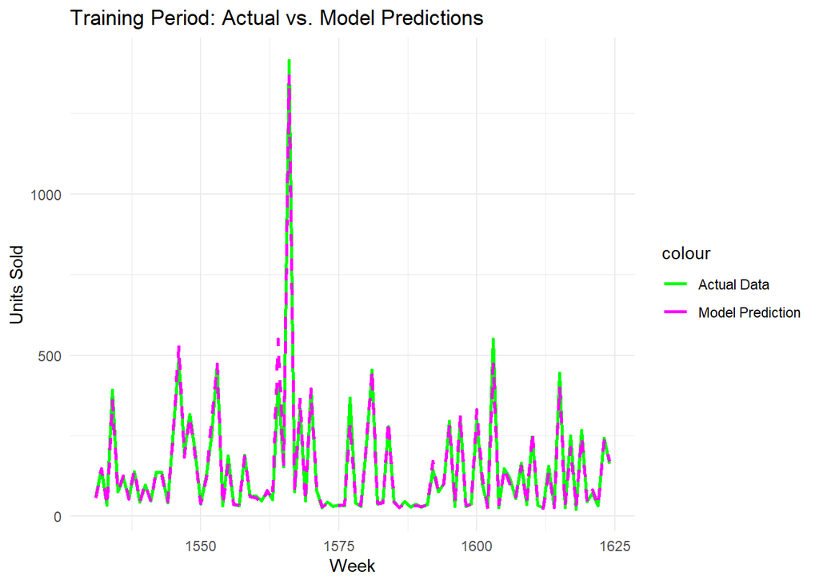

```r
formatted_training_data$Forecasted_Units <- exp(predict(integrated_linear_model, newdata = formatted_training_data))


training_period_plot <- ggplot(formatted_training_data, aes(x = WEEK)) +
  geom_line(aes(y = UNITS, color = "Actual Data"), size = 1) +
  geom_line(aes(y = Forecasted_Units, color = "Model Prediction"), size = 1, linetype = "dashed") +
  labs(title = "Training Period: Actual vs. Model Predictions",
       x = "Week",
       y = "Units Sold") +
  scale_color_manual(values = c("Actual Data" = "green", "Model Prediction" = "magenta")) +
  theme_minimal()
training_period_plot
```

```r
library(forecast)
```

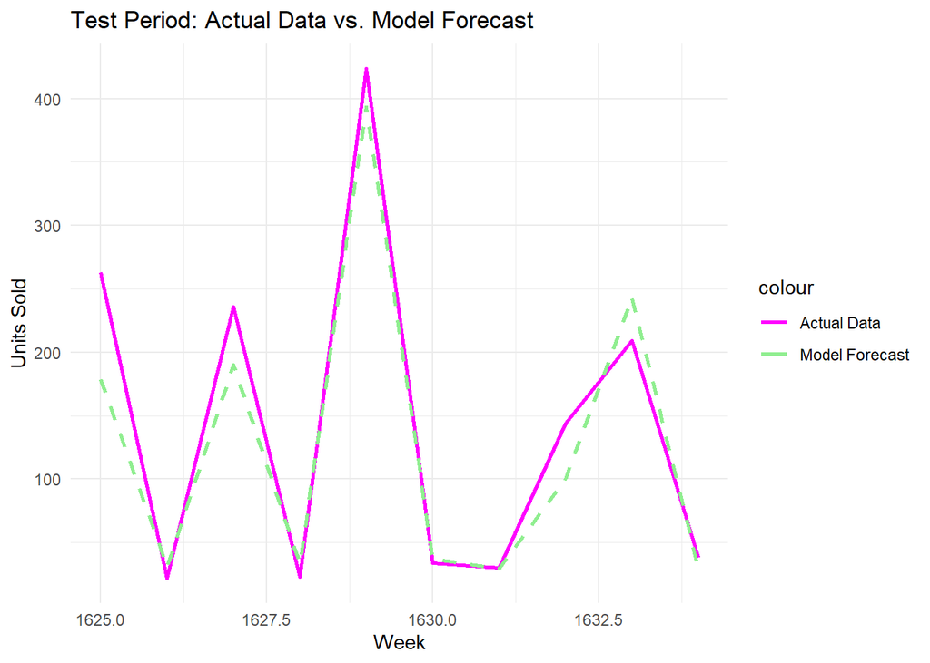

```r
TE$FEATNONE <- as.integer(TE$FEAT == "NONE")

# Forecasting ARIMA residuals
autoreg_residual_forecast <- forecast(autoregressive_model, h = length(TE$UNITS))
forecasted_autoreg_residuals <- as.vector(autoreg_residual_forecast$mean)
TE$AutoregModel_Residuals <- forecasted_autoreg_residuals

TE$Predicted <- exp(predict(integrated_linear_model, newdata = TE))

# Creating the test period plot
testing_period_plot <- ggplot(TE, aes(x = WEEK)) +
  geom_line(aes(y = UNITS, color = "Actual Data"), size = 1) +
  geom_line(aes(y = Predicted, color = "Model Forecast"), size = 1, linetype = "dashed") +
  labs(title = "Test Period: Actual Data vs. Model Forecast",
       x = "Week",
       y = "Units Sold") +
  scale_color_manual(values = c("Actual Data" = "magenta", "Model Forecast" = "lightgreen")) +
  theme_minimal()

testing_period_plot
```

#### Q5. Examine the correlation matrix between all the predictive variables considered in your analysis and comment on how the observed correlation affects the results you obtained.

#### Ans 5:

```r
formatted_training_data$LogUnitsSold <- log(formatted_training_data$UNITS)
data_for_correlation_analysis <- formatted_training_data %>%
  select(LogUnitsSold, WEEK, D, FEATNONE, P, AutoregModel_Residuals)

# Creating the correlation matrix
correlation_analysis_matrix <- cor(data_for_correlation_analysis, use = "complete.obs")

# Printing the correlation matrix
print(correlation_analysis_matrix)
```

```
##                        LogUnitsSold         WEEK            D    FEATNONE
## LogUnitsSold              1.0000000 -0.119390397  0.743785259 -0.77120754
## WEEK                     -0.1193904  1.000000000  0.008429783  0.02458228
## D                         0.7437853  0.008429783  1.000000000 -0.60198366
## FEATNONE                 -0.7712075  0.024582280 -0.601983660  1.00000000
## P                        -0.8779507  0.060075906 -0.629632600  0.72977801
## AutoregModel_Residuals    0.3477102 -0.003681841 -0.018978729  0.02541108
##                                  P AutoregModel_Residuals
## LogUnitsSold           -0.87795074            0.347710156
## WEEK                    0.06007591           -0.003681841
## D                      -0.62963260           -0.018978729
## FEATNONE                0.72977801            0.025411078
## P                       1.00000000            0.017081871
## AutoregModel_Residuals  0.01708187            1.000000000
```